# Ednet multi-class example on Iris dataset

Load the package, and bring the Iris data into the environment.

```r
library(EdNet)
data("iris")
head(iris)
```

|  | Sepal.Length | Sepal.Width | Petal.Length | Petal.Width | Species |
| --- | --- | --- | --- | --- | --- |
| 1 | 5.1 | 3.5 | 1.4 | 0.2 | setosa |
| 2 | 4.9 | 3.0 | 1.4 | 0.2 | setosa |
| 3 | 4.7 | 3.2 | 1.3 | 0.2 | setosa |
| 4 | 4.6 | 3.1 | 1.5 | 0.2 | setosa |
| 5 | 5.0 | 3.6 | 1.4 | 0.2 | setosa |
| 6 | 5.4 | 3.9 | 1.7 | 0.4 | setosa |

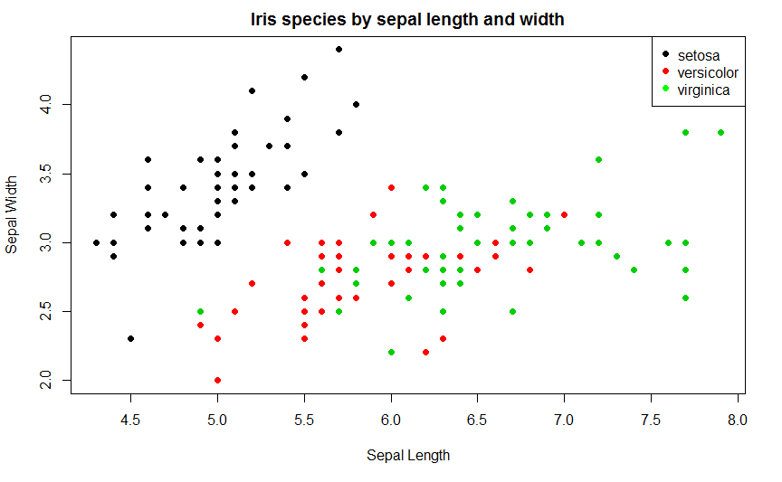

```r
# Plot sepal length v sepal width and colour by species
plot(iris$Sepal.Length, iris$Sepal.Width, col=iris$Species, pch=16,
     xlab="Sepal Length", ylab="Sepal Width", main="Iris species by sepal length and width")
legend("topright",
       legend=c("setosa", "versicolor", "virginica"),
       col=c("black", "red", "green"), pch=16)
```

Before fitting the model. For multi-class learning, `EdNetTrain` requires the input labels to be one-hot encoded. It’s also good practice to normalise input features before training.

```r
X <- sapply(iris[, 1:4], normalise)
head(X)
```

```
     Sepal.Length Sepal.Width Petal.Length Petal.Width
[1,]   -0.8976739  1.01560199    -1.335752   -1.311052
[2,]   -1.1392005 -0.13153881    -1.335752   -1.311052
[3,]   -1.3807271  0.32731751    -1.392399   -1.311052
[4,]   -1.5014904  0.09788935    -1.279104   -1.311052
[5,]   -1.0184372  1.24503015    -1.335752   -1.311052
[6,]   -0.5353840  1.93331463    -1.165809   -1.048667
```

```r
Y <- onehotEncode(iris$Species)
head(Y)
```

```
     setosa versicolor virginica
[1,]      1          0         0
[2,]      1          0         0
[3,]      1          0         0
[4,]      1          0         0
[5,]      1          0         0
[6,]      1          0         0
```

We will hold out 20 rows at random (there are 150 altogether.)

```r
set.seed(1984)
holdoutRows <- sample(1:150, 20)
```

We’re now ready to train a model. We will train a network with 3 fully-connected hidden layers with dimensions 128, 64 and 32. Each of these layers will use a `relu` activiation function and a drop-out percentage of 50%. We will train for 40 epochs with a mini-batch size of 16 using Adam optimisation.

```
[1] "Cost after 0 epochs: train-5.777205, dev-2.721248"
[1] "Cost after 40 epochs: train-1.287214, dev-0.3417474"
[1] "Best dev score achieved was 0.2857786 after 34 epochs."
```

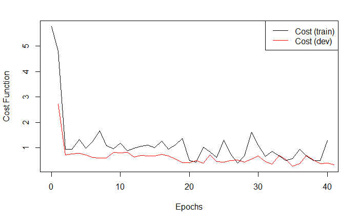

```r
modelFit <- EdNetTrain(X, Y,
                       family="multiclass",
                       learning_rate=0.01,
                       num_epochs=40,
                       hidden_layer_dims=c(128, 64, 32),
                       hidden_layer_activations="relu",
                       optimiser="Adam",
                       lambda = 0.001,
                       keep_prob=0.5,
                       mini_batch_size=16,
                       print_every_n=40L,
                       seed=1984,
                       plot=TRUE,
                       dev_set=holdoutRows)
```

The costs are calculated on the final mini-batch of an epoch (in this case only on 16 rows for the training data) which, along with the drop-out, explains the noisiness. It seems quite flat after a certain point and the goodness-of-fit on the dev set is not trending upwards so we can be reasonably happy with the number of epochs we trained for.

We can generate the predicted class probabilities by using the `predict` function.

```r
classProbs <- predict(modelFit, X)
head(classProbs)
```

```
          [,1]        [,2]        [,3]
[1,] 0.9921686 0.001581438 0.006249931
[2,] 0.9670141 0.009423178 0.023562716
[3,] 0.9838318 0.003948995 0.012219158
[4,] 0.9723469 0.007762205 0.019890933
[5,] 0.9935133 0.001252937 0.005233720
[6,] 0.9904618 0.002222856 0.007315311
```

Using the `predictedClass` function we can calculate the predicted class for each row (which is the class with the highest probability.)

```r
iris$predictions <- predictedClass(classProbs, levels(iris$Species))
head(iris)
```

|  | Sepal.Length | Sepal.Width | Petal.Length | Petal.Width | Species | predictions |
| --- | --- | --- | --- | --- | --- | --- |
| 1 | 5.1 | 3.5 | 1.4 | 0.2 | setosa | setosa |
| 2 | 4.9 | 3.0 | 1.4 | 0.2 | setosa | setosa |
| 3 | 4.7 | 3.2 | 1.3 | 0.2 | setosa | setosa |
| 4 | 4.6 | 3.1 | 1.5 | 0.2 | setosa | setosa |
| 5 | 5.0 | 3.6 | 1.4 | 0.2 | setosa | setosa |
| 6 | 5.4 | 3.9 | 1.7 | 0.4 | setosa | setosa |

Plotting these predictions on the holdout only (it is easy to generate good predictions on the training data.)

```r
dev <- iris[holdoutRows, ]
par(mfrow=c(1,2))
plot(dev$Sepal.Length, dev$Sepal.Width, col=dev$Species, pch=16,
     xlab="Sepal Length", ylab="Sepal Width", main="Actual")
plot(dev$Sepal.Length, dev$Sepal.Width, col=dev$predictions, pch=16,
     xlab="Sepal Length", ylab="Sepal Width", main="Predicted")
```

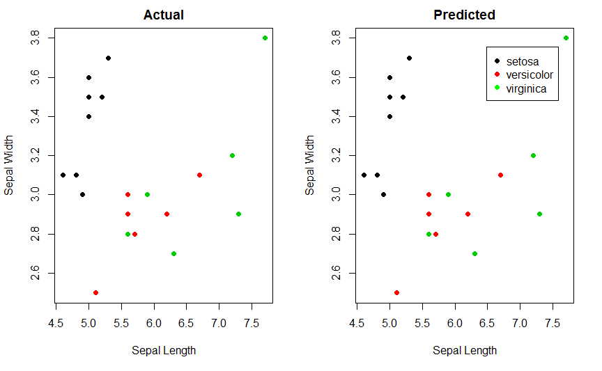

```r
legend("topright", inset=0.07,
       legend=c("setosa", "versicolor", "virginica"),
       col=c("black", "red", "green"), pch=16)
```

Predictions on the holdout data set have 100% accuracy!